# atac timecourse analysis

Roman E. Reggiardo

2022-07-07

# nb_setup

# ggplot theme

# Data

## load and parse

# Feature engineering

## parse out useful variables

## consensus peak list

# Data viz

This is a preliminary analysis that has a lot more room for growth and potential both content-wise and in terms of aesthetics. More of a survey of the major events and trends I can find quickly – I have been really swamped lately and have more time now and in the coming weeks to work on the data. In all the analysis below, I’ve removed the 24hr time points. I’ll keep digging through this next week, let me know if you have any requests, questions, or ideas. Code is hidden for ease of viewing.

## biotype time course

Over time, how many significantly enriched peaks are detected in each comparison, at each time point compared to T==0, colored by biotype.

### number of significantly enriched peaks by biotype

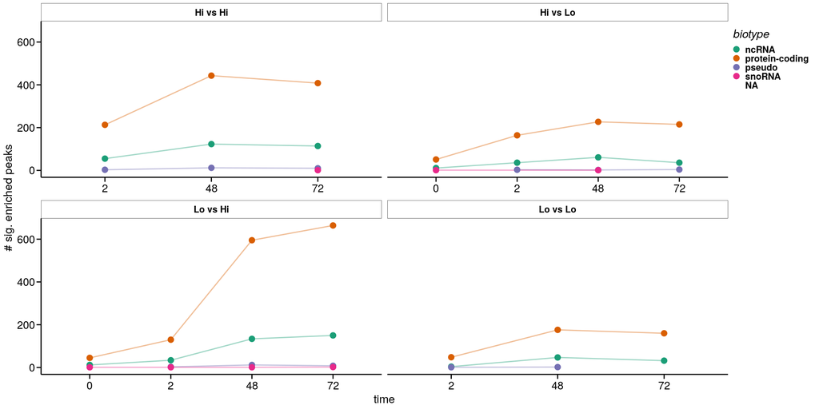

### fraction of significantly enriched peaks from each biotype

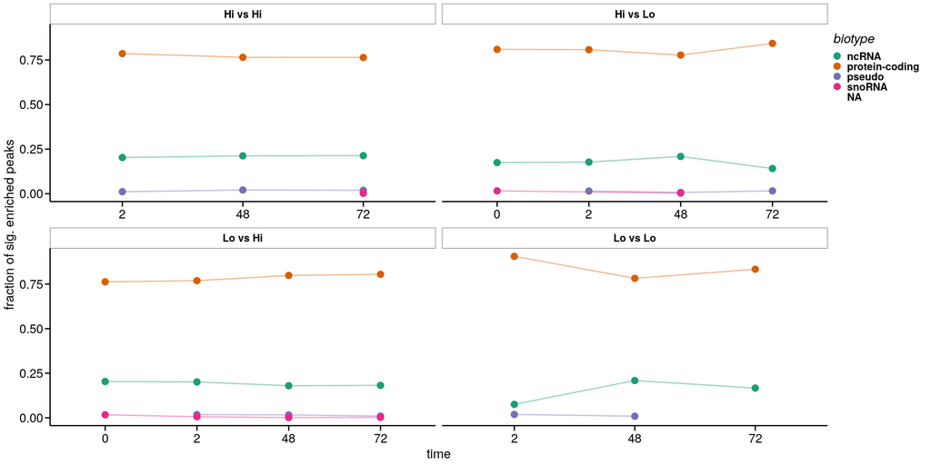

## annotation time course

Same as above but instead of biotypes we’re looking at the genomic annotations.

### number of significantly enriched peaks by annotation

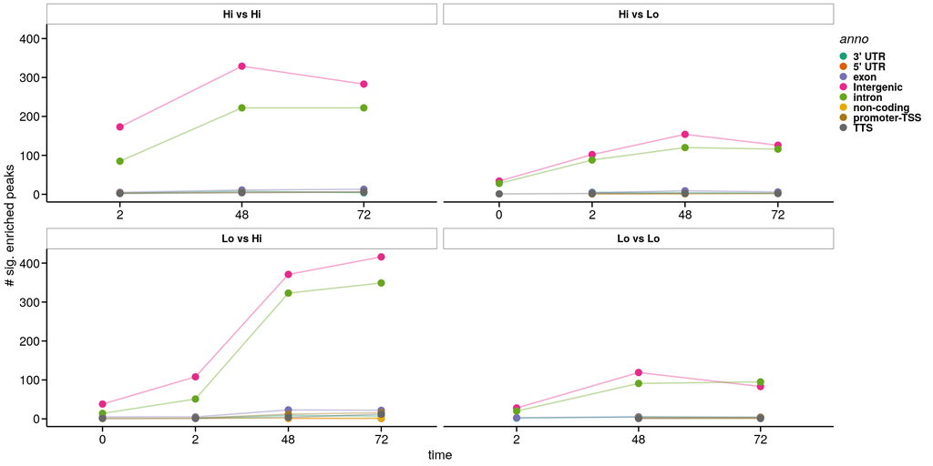

### fraction of significantly enriched peaks from each annotation

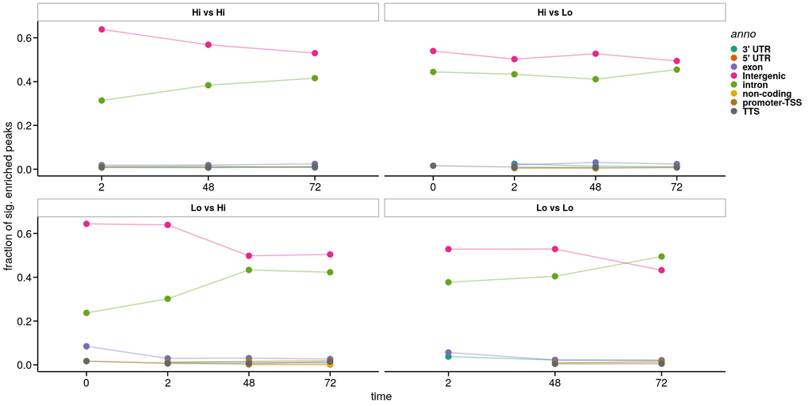

## individual peaks over time

Here I’m taking the peaks (and labeling with their associated gene) that only show up in all 4 time points for each comparison and plotting their log2Foldchange as a function of time. I think this can be expanded to characterize these 20 peaks/genes as consistent, burst, or linear/logistic responders.

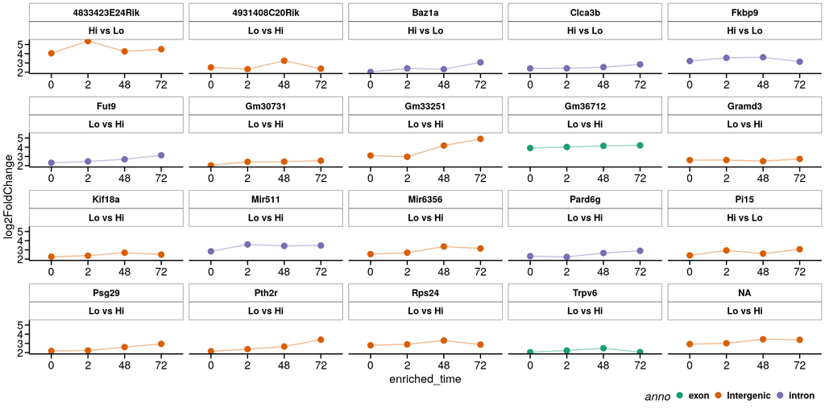